# Week5Assignment

Bin Lin

2016-10-2

1. Create a .CSV file (or optionally, a MySQL database!) that includes all of the information above. You’re encouraged to use a “wide” structure similar to how the information appears above, so that you can practice tidying and transformations as described below.
2. Read the information from your .CSV file into R, and use tidyr and dplyr as needed to tidy and transform your data.
3. Perform analysis to compare the arrival delays for the two airlines.

```r
#install.packages("dplyr")
#install.packages("tidyr")
#install.packages("ggplot2")

library(dplyr)
library(tidyr)
library(ggplot2)
```

After creating the csv file in my local machine, I loaded the data file into Rstudio.

```r
flights_delayed <- read.csv("C:/Users/blin261/Desktop/DATA607/flights_delayed.csv", header = TRUE, stringsAsFactors = FALSE)
flights_delayed
```

```
##         X     X.1 Los.Angeles Phoenix San.Diego San.Francisco Seattle
## 1  ALASKA on time         497     221       212           503    1841
## 2  ALASKA delayed          62      12        20           102     305
## 3 AM WEST on time         694    4840       383           320     201
## 4 AM WEST delayed         117     415        65           129      61
```

```r
str(flights_delayed)
```

```
## 'data.frame':    4 obs. of  7 variables:
##  $ X            : chr  "ALASKA" "ALASKA" "AM WEST" "AM WEST"
##  $ X.1          : chr  "on time" "delayed" "on time" "delayed"
##  $ Los.Angeles  : int  497 62 694 117
##  $ Phoenix      : int  221 12 4840 415
##  $ San.Diego    : int  212 20 383 65
##  $ San.Francisco: int  503 102 320 129
##  $ Seattle      : int  1841 305 201 61
```

From the raw databases, we can tell the dataset is not very tidy and appears to be “wide”. Some of the column names do not really make sense. The following code will first change the column names and the observation’s name as well.

```r
colnames(flights_delayed)[1:2] <- c("Airlines", "Punctuality")
flights_delayed$Punctuality[flights_delayed$Punctuality == "on time"] <- "on_time"
flights_delayed
```

```
##   Airlines Punctuality Los.Angeles Phoenix San.Diego San.Francisco Seattle
## 1   ALASKA     on_time         497     221       212           503    1841
## 2   ALASKA     delayed          62      12        20           102     305
## 3  AM WEST     on_time         694    4840       383           320     201
## 4  AM WEST     delayed         117     415        65           129      61
```

Then what I am doing with the following code is to transform the dataset from being “wide” to be “long”, so that all the data that we are interested in can be shown in a data frame.

```r
flights <- flights_delayed%>%
gather(Destinations, Frequency, Los.Angeles:Seattle)%>%
  spread(Punctuality, Frequency)
flights
```

```
##    Airlines  Destinations delayed on_time
## 1    ALASKA   Los.Angeles      62     497
## 2    ALASKA       Phoenix      12     221
## 3    ALASKA     San.Diego      20     212
## 4    ALASKA San.Francisco     102     503
## 5    ALASKA       Seattle     305    1841
## 6   AM WEST   Los.Angeles     117     694
## 7   AM WEST       Phoenix     415    4840
## 8   AM WEST     San.Diego      65     383
## 9   AM WEST San.Francisco     129     320
## 10  AM WEST       Seattle      61     201
```

In order to perform analysis, more variables need to be created, such as the total flights for each airline company on each destinations. In the meantime, we can also calculate the percentage of flights that were delayed. This can be accomplished using function called “mutate”.

```r
flights <- flights%>%
  mutate(total = delayed + on_time,Percentage = delayed / total)

flights
```

```
##    Airlines  Destinations delayed on_time total Percentage
## 1    ALASKA   Los.Angeles      62     497   559 0.11091234
## 2    ALASKA       Phoenix      12     221   233 0.05150215
## 3    ALASKA     San.Diego      20     212   232 0.08620690
## 4    ALASKA San.Francisco     102     503   605 0.16859504
## 5    ALASKA       Seattle     305    1841  2146 0.14212488
## 6   AM WEST   Los.Angeles     117     694   811 0.14426634
## 7   AM WEST       Phoenix     415    4840  5255 0.07897241
## 8   AM WEST     San.Diego      65     383   448 0.14508929
## 9   AM WEST San.Francisco     129     320   449 0.28730512
## 10  AM WEST       Seattle      61     201   262 0.23282443
```

```r
str(flights)
```

```
## 'data.frame':    10 obs. of  6 variables:
##  $ Airlines    : chr  "ALASKA" "ALASKA" "ALASKA" "ALASKA" ...
##  $ Destinations: chr  "Los.Angeles" "Phoenix" "San.Diego" "San.Francisco" ...
##  $ delayed     : int  62 12 20 102 305 117 415 65 129 61
##  $ on_time     : int  497 221 212 503 1841 694 4840 383 320 201
##  $ total       : int  559 233 232 605 2146 811 5255 448 449 262
##  $ Percentage  : num  0.1109 0.0515 0.0862 0.1686 0.1421 ...
```

After we create the new data frame called flights, we want to calculate the aggregate percentage of flights that were delayed for each airline. group_by function can help us calculate variables by group, in this case, the airline companies. summarize function can help us perform calculations in an aggregate scale. The result generated is a table. As shown in the following, AM WEST seems to be a better airline company overall as it has lower flights delayed rate compared to ALASKA.

```r
f <- flights%>%
  group_by(Airlines)%>%
  summarize(total_delayed = sum(delayed), total_on_time = sum(on_time), total_flights = sum(total), total_percentage = total_delayed / total_flights)
f
```

```
## # A tibble: 2 x 5
##   Airlines total_delayed total_on_time total_flights total_percentage
##      <chr>         <int>         <int>         <int>            <dbl>
## 1   ALASKA           501          3274          3775        0.1327152
## 2  AM WEST           787          6438          7225        0.1089273
```

We also want to know what is each airline companies’ flight delayed rate look like for each destination. Of course, we need to group the data by airline companies again, then use spread function to display each destinations in columnns. The observations of those variables will be percentage of flight delays. Surprisingly, for every destination, it is always the ALASKA which has relatively lower flight delayed rate.

```r
F <- flights%>%
  group_by(Airlines)%>%
  arrange(Destinations, Airlines)%>%
  select(Airlines, Destinations, Percentage)%>%
  spread(Destinations, Percentage)
F
```

```
## Source: local data frame [2 x 6]
## Groups: Airlines [2]
##
##   Airlines Los.Angeles    Phoenix San.Diego San.Francisco   Seattle
## *    <chr>       <dbl>      <dbl>     <dbl>         <dbl>     <dbl>
## 1   ALASKA   0.1109123 0.05150215 0.0862069     0.1685950 0.1421249
## 2  AM WEST   0.1442663 0.07897241 0.1450893     0.2873051 0.2328244
```

If ALASKA is able to beat AW WEST on each destinations in terms of lower flight delayed rates, how can AW WEST still be a better airline company overall? That is a question we want to ask. Actually this phenomenon has a very technical term called Simpson’s Paradox. If we want to investigate the reason behind this paradox, it is good idea to draw some graphs to have visual information about these numbers.According to the graph, we are able to know that both companies have very closed flight delayed rates. The majoy discrepancies between the two are the numbers of flights that land at Phoenix. Since most of AW WEST’s flights go to Phoenix, in addition, the flights delayed rates have been the lowest among all destinations for both airline companies in Phoenix, AW WESt will be able to take advantage of that to lower down its overall flight delayed rate.

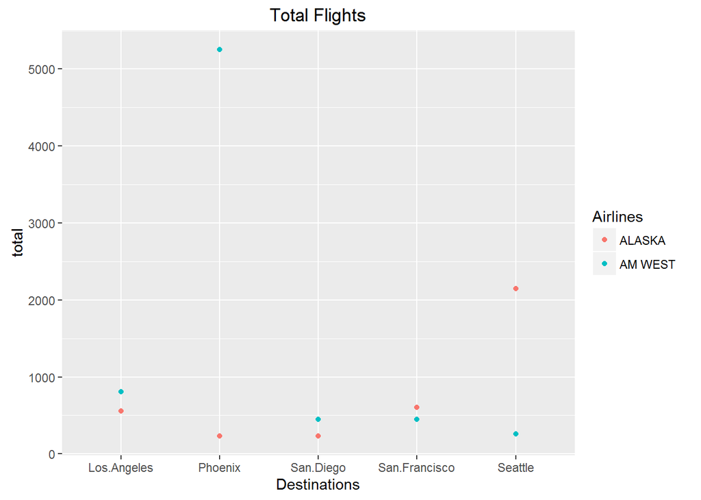

```r
ggplot(data = flights, aes(y = total, x = Destinations))+ geom_point(aes(color = Airlines)) + labs(title = "Total Flights")
```

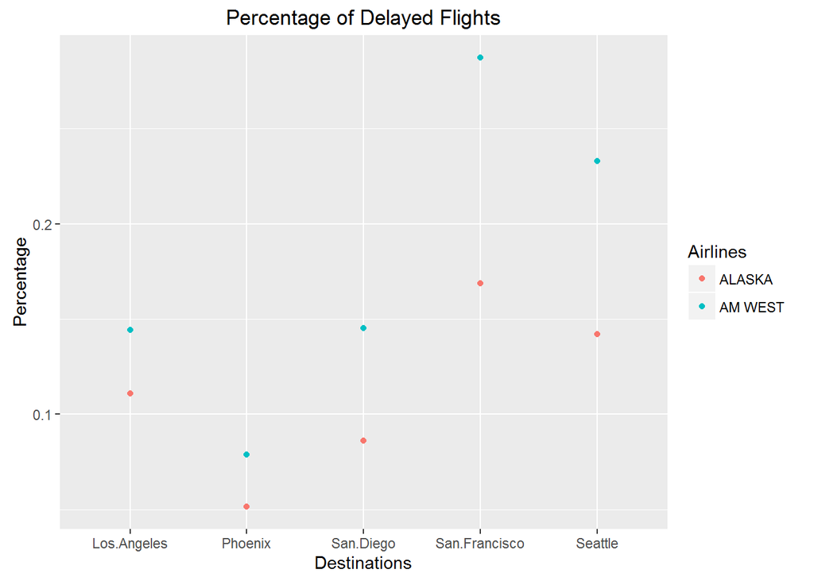

```r
ggplot(data = flights, aes(y = Percentage, x = Destinations))+ geom_point(aes(color = Airlines)) + labs(title = "Percentage of Delayed Flights")
```